# Proyecto Visualización de datos climáticos

Yustin Leiva

13/6/2021

# Carga de Librerias

```r
library(ggplot2)
library(dplyr)
library(hrbrthemes)
library(gridExtra)
library(grid)
library(showtext)
```

# Carga de datos

En este caso vamos a trabajar con los datos climáticos de liberia

```r
dat <- read.csv("liberia_datos_climaticos.csv", sep = ",", na.strings="" , dec=",")
```

El siguiente paso es limpiar cuidadosamente los datos en caso de celdas vacías, en este caso se usará la función **na.omit** para obtener un nuevo dataframe limpio de celdas vacías.

```r
newdata <- na.omit(dat)
```

Ahora para una mejor manipulación de los datos se cambiarán los nombres predeterminados que traen el conjunto de datos por unos más fáciles de trabajar, en este caso con la función **rename**.

```r
newdata <-
  newdata %>%
  rename(Fecha = Date,
         Temperatura = Temperatura..Celsius.,
         HumedadRelativa = HumedadRelativa....,
         Velocidadviento = VelocidadViento..m.s.,
         Lluvia = Lluvia..mm.,
         Irradiación = Irradiacion..W.m2.,
         EvapoTranspiracion = EvapoTranspiracion..mm.)
```

Es necesario también establecer un formato para la fecha para los ejercicios futuros, esto simplemente con el comando **as.Date**.

```r
newdata$Fecha <- as.Date(newdata$Fecha, "%d/%m/%Y")
```

# Creación de Histogramas

En este caso utilizaremos el paquete ggplot2 para la creación de una serie de histogramas, y por último la función grid para ordernalos todos en un solo panel.

## Temperatura

```r
a <- ggplot(newdata, aes(x = Temperatura)) +
  geom_histogram(binwidth = 0.1,
                 color = "black",
                 fill = "red") +
  ggtitle("Temperatura") +
  xlab("Temperatura(°C)") +
  ylab("Frecuencia(%)") +
  theme_dark()
```

## Humedad Relativa

```r
b <- ggplot(newdata, aes(x = HumedadRelativa)) +
  geom_histogram(binwidth = 0.5,
                 color = "black",
                 fill = "#1E90FF") +
  ggtitle("Humedad Relativa") +
  xlab("Humedad relativa(%)") +
  ylab("Frecuencia(%)") +
  theme_dark()
```

## Velocidad del viento

```r
c <- ggplot(newdata, aes(x = Velocidadviento)) +
  geom_histogram(binwidth = 0.4,
                 color = "black",
                 fill = "#808080") +
  ggtitle("Velocidad Viento") +
  xlab("Velocidad del viento (m/s)") +
  ylab("Frecuencia(%)") +
  theme_dark()
```

## Lluvia

```r
d <- ggplot(newdata, aes(x = Lluvia)) +
  geom_histogram(binwidth = 10,
                 color = "black",
                 fill = "#0000FF") +
  ggtitle("Lluvia") +
  xlab("Precipitación(mm)") +
  ylab("Frecuencia(%)") +
  theme_dark()
```

## Irradiación

```r
e <- ggplot(newdata, aes(x = Irradiación)) +
  geom_histogram(binwidth = 8,
                 color = "black",
                 fill = "#FF4500") +
  ggtitle("Irradición") +
  xlab("Irradiación(wm2)") +
  ylab("Frecuencia(%)") +
  theme_dark()
```

##Evapotranspiración

```r
f <- ggplot(newdata, aes(x = EvapoTranspiracion)) +
  geom_histogram(binwidth = 0.4,
                 color = "black",
                 fill = "#B0E0E6") +
  ggtitle("Evapotranspiracion") +
  xlab("Evapotranspiracion(mm)") +
  ylab("Frecuencia(%)") +
  theme_dark()
```

# Resultado de los histogramas

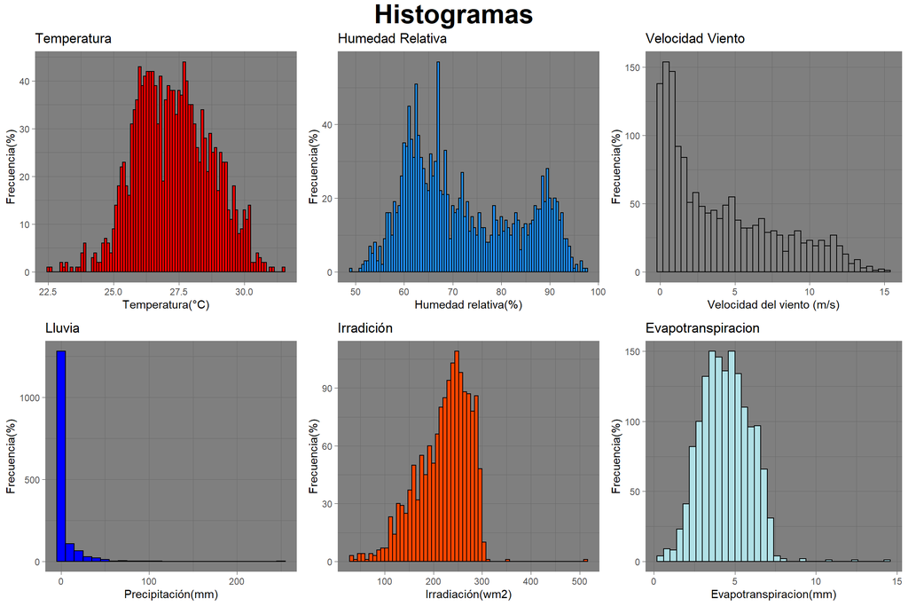

```r
grid.arrange(a, b, c, d, e, f, nrow=2,
       top= textGrob("Histogramas",gp=gpar(fontsize=25,font=15)))
```

# Promediando variables mensuales

Se crearon nuevos dataframes gracias a la función taplly. En este caso para promediar mensualmente las variables de temperatura, humedad, velocidad de viento e irradiación, mientras que por otra parte se sumó la lluvia y evapotranspiración a valores mensuales.

```r
prom_mensual_temp <- data.frame(mes = 1:12,
                                Temperatura = tapply
                                (newdata$Temperatura,
                                  format(newdata$Fecha, format = "%m"),
                                  FUN = mean))

rom_mensual_humedad <- data.frame(mes = 1:12,
                                HumedadRelativa = tapply
                                (newdata$HumedadRelativa,
                                  format(newdata$Fecha, format = "%m"),
                                  FUN = mean))

prom_mensual_viento <- data.frame(mes = 1:12,
                                  VelocidadViento = tapply
                                  (newdata$Velocidadviento,
                                    format(newdata$Fecha, format = "%m"),
                                    FUN = mean))

prom_mensual_irradi <- data.frame(mes = 1:12,
                                  Irradiación = tapply
                                  (newdata$Irradiación,
                                    format(newdata$Fecha, format = "%m"),
                                    FUN = mean))

suma_mensual_lluvia <- data.frame(mes = 1:12,
                                  Lluvia = tapply
                                  (newdata$Lluvia,
                                    format(newdata$Fecha, format = "%m"),
                                    FUN = sum))

suma_mensual_evapo <- data.frame(mes = 1:12,
                                  EvapoTranspiración = tapply
                                  (newdata$EvapoTranspiracion,
                                    format(newdata$Fecha, format = "%m"),
                                    FUN = sum))
```

# Creación de gráficos de lineas

Se crearon gráficos igualmente mediante la función ggplot y se unieron gracias a la función grid.

# Temperatura

```r
g <- ggplot(prom_mensual_temp, aes(x=mes, y=Temperatura )) +
  geom_line(colour="red", lwd = 1, lty = 1)+
  ggtitle(" Promedio Temperatura") +
  xlab("Mes") +
  ylab("Temperatura(°C)")+
    theme_bw()
```

# Humedad Relativa

```r
h <- ggplot(rom_mensual_humedad, aes(x=mes, y=HumedadRelativa )) +
  geom_line(colour="#076DFD", lwd = 1.5, lty = 2) +
  ggtitle("Promedio Humedad Relativa") +
  xlab("Mes") +
  ylab("Humedad Relativa(%)")+
   theme_bw()
```

# Irradiación

```r
i <- ggplot(prom_mensual_irradi, aes(x=mes, y=Irradiación )) +
  geom_line(colour="#FF4500", lwd = 1.5, lty = 3) +
  ggtitle("Promedio de Irradiación") +
  xlab("Mes") +
  ylab("Irradiación(Mw2)")+
    theme_bw()
```

# Velocidad de viento

```r
j <- ggplot(prom_mensual_viento, aes(x=mes, y=VelocidadViento )) +
  geom_line(colour="#808080", lwd = 1.5, lty = 4) +
  ggtitle("Promedio Velocidad de viento") +
  xlab("Mes") +
  ylab("Velocidad del viento(ms)")+
   theme_bw()
```

# Evapotranspiración

```r
k <- ggplot(suma_mensual_evapo, aes(x=mes, y=EvapoTranspiración )) +
  geom_line(colour="#B0E0E6", lwd = 1.5, lty = 5) +
  ggtitle("Suma de Evapotranspiración") +
  xlab("Mes") +
  ylab("Evapotranspiración") +
    theme_bw()
```

# Lluvia

```r
l <- ggplot(suma_mensual_lluvia, aes(x=mes, y=Lluvia )) +
  geom_line(colour="#0000FF", lwd = 1.5, lty = 6) +
  ggtitle("Suma de Lluvia") +
  xlab("Mes") +
  ylab("Lluvia(mm)") +
  theme_bw()
```

#Resultados

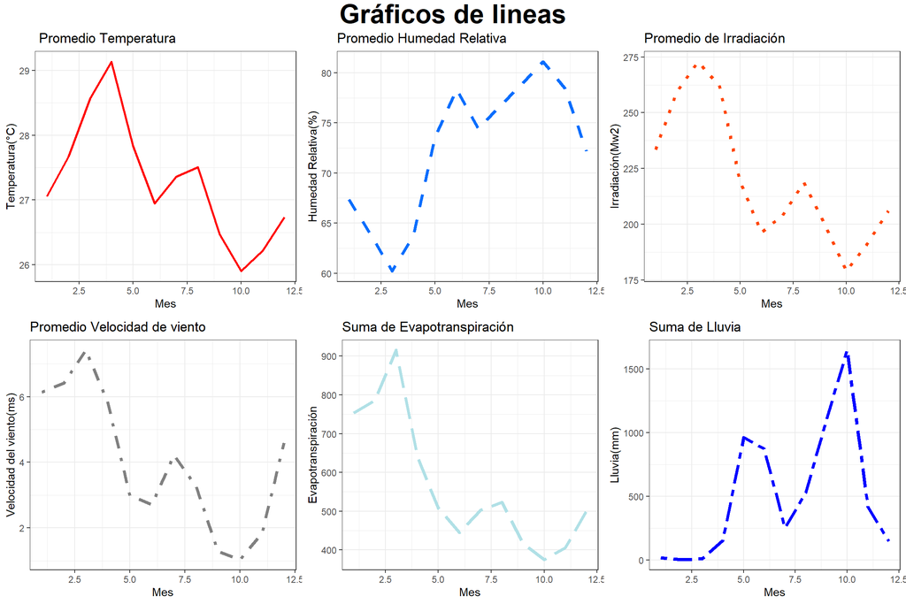

```r
grid.arrange(g, h, i, j, k, l, nrow=2,
             top= textGrob("Gráficos de lineas",gp=gpar(fontsize=25,font=15)))
```

# Creación de gráficos de dispersión para relacionar variables.

Igualmente se crearon con ggplot2 y se unieron mediante grid. Se relacionaron las variables que se muestran al final.

## Temperatura y Humedad Relativa

```r
m <- ggplot(newdata, aes(x = Temperatura)) +
  geom_point(
    aes(y = HumedadRelativa)
  ) +
  ggtitle(" Humedad Relativa y Temperatura") +
  xlab("Temperatura(C)") +
  ylab("Humedad Relativa(%)") +
  theme_get()
```

## Velocidad de viento y lluvia

```r
n <- ggplot(newdata, aes(x = Velocidadviento)) +
  geom_point(
    aes(y = Lluvia)
  ) +
  ggtitle("Velocidad de Viento y Lluvia") +
  xlab("Velocidad del viento(ms)") +
  ylab("Lluvia(mm)") +
  theme_get()
```

## Irradiación y Evapotranspiración

```r
o <- ggplot(newdata, aes(x = Irradiación)) +
  geom_point(
    aes(y = EvapoTranspiracion)
  ) +
  ggtitle(" Irradiación y EvapoTranspiración") +
  xlab("Irradiación(Wm2)") +
  ylab("Evapotranspiración(mm)") +
  theme_get()
```

## Evapotranspiración

```r
p <- ggplot(newdata, aes(x = EvapoTranspiracion)) +
  geom_point(
    aes(y = Lluvia)
  ) +
  ggtitle(" Evapotranspiración y lluvia") +
  xlab("EvapoTranspiracion(mm)") +
  ylab("Lluvia(mm)") +
  theme_get()
```

## Irradiación y Temperatura

```r
q <- ggplot(newdata, aes(x = Irradiación)) +
  geom_point(
    aes(y = Temperatura)
  ) +
  ggtitle(" Irradiación y Temperatura") +
  xlab("Irradiación(Wm2)") +
  ylab("Temperatura(°C)") +
  theme_get()
```

## Lluvia y Humedad

```r
r <- ggplot(newdata, aes(x = HumedadRelativa)) +
  geom_point(
    aes(y = Lluvia)
  ) +
  ggtitle( "Humedad Relativa y Lluvia") +
  xlab("Humedad Relativa(%)") +
  ylab("Lluvia(mm)") +
  theme_get()
```

#Resultados

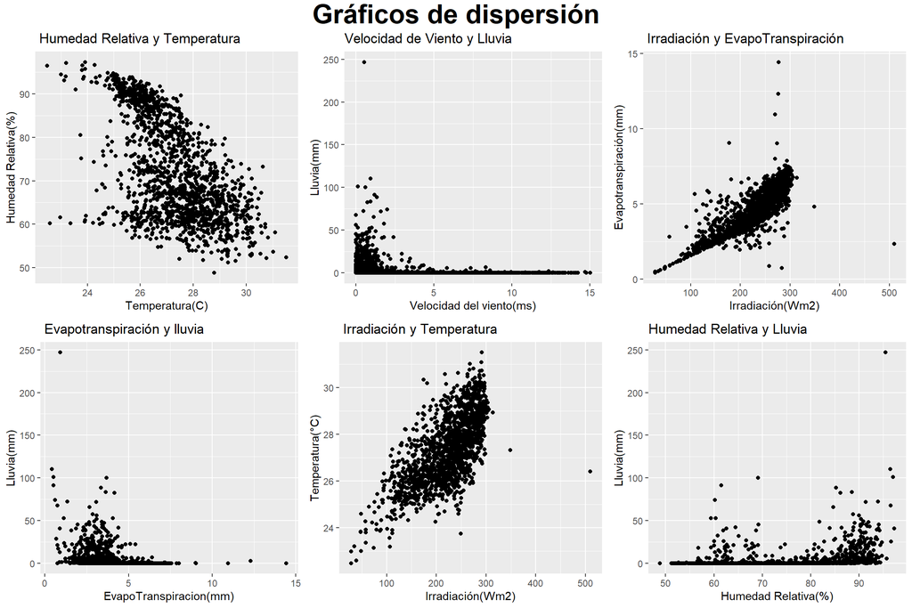

```r
grid.arrange(m, n, o, p, q, r, nrow=2,
             top= textGrob("Gráficos de dispersión",gp=gpar(fontsize=25,font=15)))
```